# LM: Introduction

2018-05-15

## The Linear Model: LM

- 2.0 Introduction
- 2.1 Point estimates
- 2.2 Uncertainty in point estimates
- 2.3 Tests
- 2.4 Assumptions and Outliers
- 2.5 Let's practice more

## You will learn in this session

- how to write a linear model (using two notations)
- what a response, a design matrix and model parameters are
- how to understand the design matrix
- that the meaning of the parameter depends on the design matrix
- that the design matrix depends on the formula, the data and the contrats
- how to simulate the data for a linear model

## Definition and notations

## What is a Linear Model (LM)?

### What is a statistical model?

### *A statistical model represents, often in considerably idealized form, the data-generating process.* [(wikipedia)](https://en.wikipedia.org/wiki/Statistical_model)

### What is a linear model?

### *The data-generating process is assumed to be a linear function: it is constructed from a set of terms by multiplying each term by a constant (a model parameter) and adding the results .*

## Mathematical notation of LM: simple notation

\(y_i = \beta_0 + \beta_1 \times x_{1,i} + \beta_2 \times x_{2,i} + \dots + \beta_{p} \times x_{p,i} + \epsilon_i\)

- \(y_i\) = the observations to explain / response variable / dependent variable
- \(x_{j,i}\) = constants derived from the predictors / explanatory variables / independent variables
- \(\beta_j\) = the regression coefficients / model parameters
- \(\epsilon_i\) = the errors / residual errors

## Mathematical notation of LM: matrix notation

\(Y = X \beta + \epsilon\)

\[ \begin{bmatrix} y_1 \\ y_2 \\ y_3 \\ \dots \\ y_n \end{bmatrix} = \begin{bmatrix} 1 & x_{1,1} & x_{1,2} & \dots & x_{1,p} \\ 1 & x_{2,1} & x_{2,2} & \dots & x_{2,p} \\ 1 & x_{3,1} & x_{3,2} & \dots & x_{3,p} \\ \dots & \dots & \dots & \dots & \dots \\ 1 & x_{n,1} & x_{n,2} & \dots & x_{n,p} \end{bmatrix} \begin{bmatrix} \beta_0 \\ \beta_1 \\ \beta_2 \\ \dots \\ \beta_p \end{bmatrix} + \begin{bmatrix} \epsilon_1 \\ \epsilon_2 \\ \epsilon_3 \\ \dots \\ \epsilon_n \end{bmatrix} \]

- \(Y\) = the vector of observations
- \(X\) = a matrix called the design (or model) matrix
- \(\beta\) = the vector of model parameters
- \(\epsilon\) = the vector of errors

## The response

## What kind of responses LM can handle?

- one dimension: \(n \times 1\)
- continuous
- no other restriction

## The design matrix

## The design matrix

### It is the representation of the predictors!

- multi-dimensional: \(n \times p\) with \(n > p\)
- deduced from the predictors
- known and measured without error
- columns should be linearly independent

Sad but `TRUE`:

### You cannot interpret model parameters correctly without knowing the design matrix of the model!!!

## How to create the design matrix?

```r
somedata <- data.frame(x1 = 1:6)
(mm <- model.matrix(object = ~ x1, data = somedata))
```

```
##   (Intercept) x1
## 1           1  1
## 2           1  2
## 3           1  3
## 4           1  4
## 5           1  5
## 6           1  6
## attr(,"assign")
## [1] 0 1
```

The term "`~ x1`" is an object of class formula.

Note: the functions fitting linear models will call `model.matrix()` for you.

## Ploting the design matrix

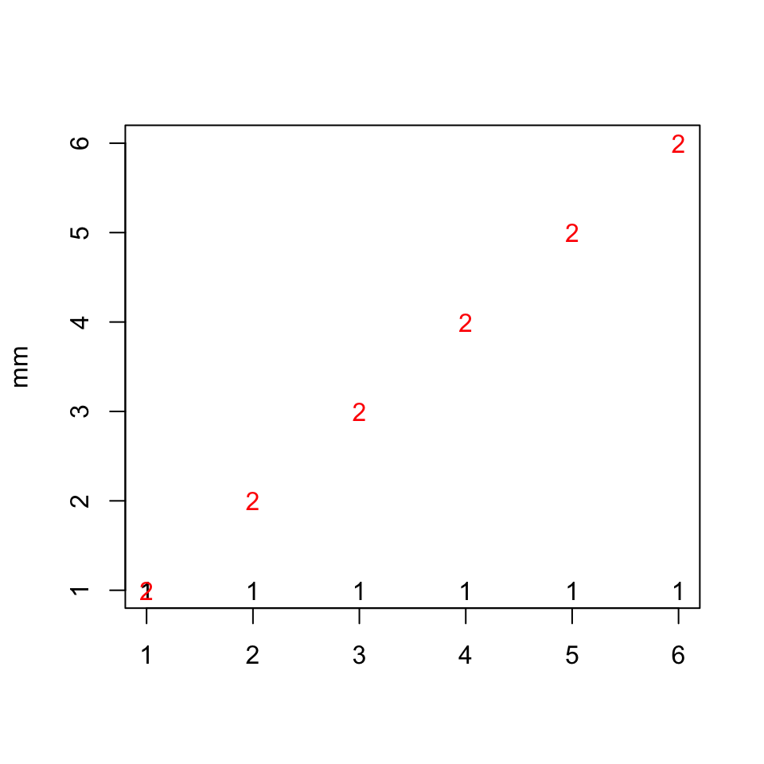

```r
matplot(mm)
```

## A design matrix without intercept

```r
model.matrix(object = ~ 0 + x1, data = somedata)
```

```
##   x1
## 1  1
## 2  2
## 3  3
## 4  4
## 5  5
## 6  6
## attr(,"assign")
## [1] 1
```

```r
model.matrix(object = ~ -1 + x1, data = somedata)
```

```
##   x1
## 1  1
## 2  2
## 3  3
## 4  4
## 5  5
## 6  6
## attr(,"assign")
## [1] 1
```

## A design matrix with function calls

```r
(m <- model.matrix(object = ~ x1 + log(x1) + sqrt(x1) + I(x1-1), data = somedata))
```

```
##   (Intercept) x1   log(x1) sqrt(x1) I(x1 - 1)
## 1           1  1 0.0000000 1.000000         0
## 2           1  2 0.6931472 1.414214         1
## 3           1  3 1.0986123 1.732051         2
## 4           1  4 1.3862944 2.000000         3
## 5           1  5 1.6094379 2.236068         4
## 6           1  6 1.7917595 2.449490         5
## attr(,"assign")
## [1] 0 1 2 3 4
```

Note that this design matrix is ill defined as some columns are linearly dependent.

```r
all.equal(det(crossprod(m)), 0)  ## quick test for linear dependence (cf later)
```

```
## [1] TRUE
```

## A design matrix with polynomials

```r
(DM_raw <- model.matrix(object = ~ poly(x1, 2, raw = TRUE), data = somedata))
```

```
##   (Intercept) poly(x1, 2, raw = TRUE)1 poly(x1, 2, raw = TRUE)2
## 1           1                        1                        1
## 2           1                        2                        4
## 3           1                        3                        9
## 4           1                        4                       16
## 5           1                        5                       25
## 6           1                        6                       36
## attr(,"assign")
## [1] 0 1 1
```

## A design matrix with polynomials

```r
(DM_ortho <- model.matrix(object = ~ poly(x1, 2), data = somedata))
```

```
##   (Intercept) poly(x1, 2)1 poly(x1, 2)2
## 1           1   -0.5976143    0.5455447
## 2           1   -0.3585686   -0.1091089
## 3           1   -0.1195229   -0.4364358
## 4           1    0.1195229   -0.4364358
## 5           1    0.3585686   -0.1091089
## 6           1    0.5976143    0.5455447
## attr(,"assign")
## [1] 0 1 1
```

Looking at the design matrix shows whether some transformations are happening behind the scenes. This is important as when it happens model parameters should be interpreted accordingly.

## A design matrix with a factor

```r
somedata$x2 <- c(10, 11, 12, 13, 14, 15)
somedata$x3 <- factor(c("b", "b", "a", "a", "c", "c"))
model.matrix(object = ~ x1 + x2 + x3, data = somedata)
```

```
##   (Intercept) x1 x2 x3b x3c
## 1           1  1 10   1   0
## 2           1  2 11   1   0
## 3           1  3 12   0   0
## 4           1  4 13   0   0
## 5           1  5 14   0   1
## 6           1  6 15   0   1
## attr(,"assign")
## [1] 0 1 2 3 3
## attr(,"contrasts")
## attr(,"contrasts")$x3
## [1] "contr.treatment"
```

This parameterization of factors such as `x3` follows the so-called contrast matrix "treatment".

It is the easiest one to interpret and the one use by default in R (but not in all software).

## Interpreting the treatment contrast

```r
model.matrix(object = ~ x3, data = somedata)
```

```
##   (Intercept) x3b x3c
## 1           1   1   0
## 2           1   1   0
## 3           1   0   0
## 4           1   0   0
## 5           1   0   1
## 6           1   0   1
## attr(,"assign")
## [1] 0 1 1
## attr(,"contrasts")
## attr(,"contrasts")$x3
## [1] "contr.treatment"
```

- The intercept represents the mean of the baseline (here, reference level = `"a"`).
- `x3b` represents the mean of `"b"` minus the mean of the baseline.
- `x3c` represents the mean of `"c"` minus the mean of the baseline.

Note: in R the default level of reference is always the first level of a factor (which level is first can be changed).

## There are alternative contrasts parametrizations!

```r
model.matrix(object = ~ x1 + x2 + x3, data = somedata, contrasts.arg = list(x3 = "contr.helmert"))
```

```
##   (Intercept) x1 x2 x31 x32
## 1           1  1 10   1  -1
## 2           1  2 11   1  -1
## 3           1  3 12  -1  -1
## 4           1  4 13  -1  -1
## 5           1  5 14   0   2
## 6           1  6 15   0   2
## attr(,"assign")
## [1] 0 1 2 3 3
## attr(,"contrasts")
## attr(,"contrasts")$x3
## [1] "contr.helmert"
```

Alternative parameterizations of the contrast matrix can ease convergence in GLM(M) (for continuous variable) and can allow for testing specific hypotheses or fit particular experimental design (for qualitative variables).

It will not change the predictions, the likelihood, the AIC, etc… only the parameter values and their interpretation.

## Interim: the product XTX

The product XTX is essential for many computations around linear models.

It represents all pairwise products between the columns of the design matrix.

```r
X <- matrix(c(1, 1, 1, 1, 2, 3, 4, 5, 6), byrow = FALSE, ncol = 3)
(XTX_1 <- t(X) %*% X)
```

```
##      [,1] [,2] [,3]
## [1,]    3    6   15
## [2,]    6   14   32
## [3,]   15   32   77
```

```r
XTX_2 <- crossprod(X)

XTX_3 <- matrix(0, nrow = 3, ncol = 3)

for (i in 1:3) for (j in 1:3) XTX_3[i, j] <- sum(X[, i]*X[, j])

identical(XTX_1, XTX_2) & identical(XTX_1, XTX_3)
```

```
## [1] TRUE
```

## Why make things more complex?

### For technical reasons

```r
crossprod(DM_raw)  ## high values mean that predictors are colinear -> will be hard to fit
```

```
##                          (Intercept) poly(x1, 2, raw = TRUE)1 poly(x1, 2, raw = TRUE)2
## (Intercept)                        6                       21                       91
## poly(x1, 2, raw = TRUE)1          21                       91                      441
## poly(x1, 2, raw = TRUE)2          91                      441                     2275
```

```r
zapsmall(crossprod(DM_ortho))  ## 0 means that predictors are orthogonal -> will be easy to fit
```

```
##              (Intercept) poly(x1, 2)1 poly(x1, 2)2
## (Intercept)            6            0            0
## poly(x1, 2)1           0            1            0
## poly(x1, 2)2           0            0            1
```

It produces a symetric diagonal matrix. Those are particularly math friendly.

## Why make things more complex?

### For technical reasons

```r
somedata2 <- data.frame(x = factor(c("a", "b", "c")))
m <- model.matrix(object = ~ x, data = somedata2, contrasts.arg = list(x = "contr.helmert"))
crossprod(m)
```

```
##             (Intercept) x1 x2
## (Intercept)           3  0  0
## x1                    0  2  0
## x2                    0  0  6
```

The predictors in Helmert contrasts are also orthogonal. It also produces a symetric diagonal matrix.

## Why make things more complex?

### To ease the interpretation

```
##   (Intercept) x1 x2
## 1           1 -1 -1
## 2           1  1 -1
## 3           1  0  2
## attr(,"assign")
## [1] 0 1 1
## attr(,"contrasts")
## attr(,"contrasts")$x
## [1] "contr.helmert"
```

## Why make things more complex?

### To ease the interpretation

```r
model.matrix(object = ~ x, data = somedata2, contrasts.arg = list(x = "contr.sum"))
```

```
##   (Intercept) x1 x2
## 1           1  1  0
## 2           1  0  1
## 3           1 -1 -1
## attr(,"assign")
## [1] 0 1 1
## attr(,"contrasts")
## attr(,"contrasts")$x
## [1] "contr.sum"
```

- The intercept thus represents the mean of the mean of all groups. (nice!)
- `x1` represents the mean of the first group minus the mean of the mean of all groups. (nice!)
- `x2` represents the mean of the second group minus the mean of the mean of all groups. (nice!)

Note: not much used by R users (because not the default) but seems more useful when there is no clear control.

## Understanding factorial design

```r
data(poison, package = "fastR")  ##  ?fastR::poison for description
poison$treat <- factor(poison$Treatment)
poison$poison <- factor(poison$Poison)
m <- model.matrix( ~ poison + treat, data = poison)
head(m)
```

```
##   (Intercept) poison2 poison3 treat2 treat3 treat4
## 1           1       0       0      0      0      0
## 2           1       0       0      0      0      0
## 3           1       0       0      0      0      0
## 4           1       0       0      0      0      0
## 5           1       0       0      1      0      0
## 6           1       0       0      1      0      0
```

## Understanding factorial design

```r
crossprod(m)
```

```
##             (Intercept) poison2 poison3 treat2 treat3 treat4
## (Intercept)          48      16      16     12     12     12
## poison2              16      16       0      4      4      4
## poison3              16       0      16      4      4      4
## treat2               12       4       4     12      0      0
## treat3               12       4       4      0     12      0
## treat4               12       4       4      0      0     12
```

```r
with(poison, table(treat, poison))
```

```
##      poison
## treat 1 2 3
##     1 4 4 4
##     2 4 4 4
##     3 4 4 4
##     4 4 4 4
```

Note: this works only with the contrast matrix "treatment".

## A design matrix with interactions

```r
model.matrix(object = ~ x1 * x2 + x1 * x3, data = somedata)
```

```
##   (Intercept) x1 x2 x3b x3c x1:x2 x1:x3b x1:x3c
## 1           1  1 10   1   0    10      1      0
## 2           1  2 11   1   0    22      2      0
## 3           1  3 12   0   0    36      0      0
## 4           1  4 13   0   0    52      0      0
## 5           1  5 14   0   1    70      0      5
## 6           1  6 15   0   1    90      0      6
## attr(,"assign")
## [1] 0 1 2 3 3 4 5 5
## attr(,"contrasts")
## attr(,"contrasts")$x3
## [1] "contr.treatment"
```

Interactions allow consideration of the effect of one predictor dependent on the value taken by other(s). If interactions are not considered, effects are assumed to be independent.

## A design matrix with interactions

```r
model.matrix(object = ~ x1 * x2 + x1 * x3, data = somedata, contrasts.arg = list(x3 = "contr.sum"))
```

```
##   (Intercept) x1 x2 x31 x32 x1:x2 x1:x31 x1:x32
## 1           1  1 10   0   1    10      0      1
## 2           1  2 11   0   1    22      0      2
## 3           1  3 12   1   0    36      3      0
## 4           1  4 13   1   0    52      4      0
## 5           1  5 14  -1  -1    70     -5     -5
## 6           1  6 15  -1  -1    90     -6     -6
## attr(,"assign")
## [1] 0 1 2 3 3 4 5 5
## attr(,"contrasts")
## attr(,"contrasts")$x3
## [1] "contr.sum"
```

## The model parameters

## Model parameters:

- one dimension: \(p \times 1\) vector
- fixed non-observable quantities

### They are used to convert each column from the design matrix into units of the response variable.

### The meaning of the parameters always depends on the design matrix!!!

Consequence: if what the design matrix looks like is unclear for the reader, you must provide information (e.g. contrasts used, number of levels…).

## Alternative parameterizations of equivalent design matrices

Alternative parameterization of equivalent design matrices lead to the same predictions!

This function converts parameters between alternative (but equivalent) design matrices:

```r
convert_betaXA_to_betaXB <- function(XA, XB, betaXA) {
  ## Test that inputs are OK:
  if (!any(dim(XA) == dim(XB)))   stop("design matrices differ in size")
  if (ncol(XA) != length(betaXA)) stop("betaXA of wrong length")
  ## Identify parameters that need to be converted
  id_col_keep <- which(apply(XA != XB, 2, sum) != 0) ## index columns to keep
  if (all(XA[, 1] == 1)) id_col_keep <- c(1, id_col_keep) ## add intercept
  id_col_drop <- setdiff(1:ncol(XA), id_col_keep) ## index columns to discard
  ## Conversion per se:
  betaXB_temp <- solve(coef(lm.fit(XA[, id_col_keep], XB[, id_col_keep])), betaXA[id_col_keep])
  ## Put back non converted parameters into output
  betaXB <- numeric(length(betaXA))
  betaXB[id_col_keep] <- betaXB_temp
  betaXB[id_col_drop] <- betaXA[id_col_drop]
  ## Output
  return(betaXB)
}
## homemade: this function may break in some legitimate cases...
```

## The example of polynomials

```r
DM_raw
```

```
##   (Intercept) poly(x1, 2, raw = TRUE)1 poly(x1, 2, raw = TRUE)2
## 1           1                        1                        1
## 2           1                        2                        4
## 3           1                        3                        9
## 4           1                        4                       16
## 5           1                        5                       25
## 6           1                        6                       36
## attr(,"assign")
## [1] 0 1 1
```

```r
DM_ortho
```

```
##   (Intercept) poly(x1, 2)1 poly(x1, 2)2
## 1           1   -0.5976143    0.5455447
## 2           1   -0.3585686   -0.1091089
## 3           1   -0.1195229   -0.4364358
## 4           1    0.1195229   -0.4364358
## 5           1    0.3585686   -0.1091089
## 6           1    0.5976143    0.5455447
## attr(,"assign")
## [1] 0 1 1
```

## The example of polynomials

```r
convert_betaXA_to_betaXB(XA = DM_raw, XB = DM_ortho, betaXA = c(1, 2, -2))
```

```
## [1] -22.33333 -50.19960 -12.22020
```

## The example of polynomials

```r
DM_raw %*% c(1, 2, -2)  ## predictions
```

```
##   [,1]
## 1    1
## 2   -3
## 3  -11
## 4  -23
## 5  -39
## 6  -59
```

```r
round(DM_ortho %*% c(-22.33333, -50.19960, -12.22020), 3)
```

```
##   [,1]
## 1    1
## 2   -3
## 3  -11
## 4  -23
## 5  -39
## 6  -59
```

## The example of treatment vs Helmert

```r
DM_treat <- model.matrix(object = ~ x1 + x2 + x3, data = somedata, contrasts.arg = list(x3 = "contr.treatment"))
DM_Helm <- model.matrix(object = ~ x1 + x2 + x3, data = somedata, contrasts.arg = list(x3 = "contr.helmert"))
beta_treat <- matrix(c(50, 1.5, 20, 2, 3))
(beta_Helm <- convert_betaXA_to_betaXB(XA = DM_treat, XB = DM_Helm, betaXA = beta_treat))
```

```
## [1] 51.6666667  1.5000000 20.0000000  1.0000000  0.6666667
```

```r
DM_treat %*% beta_treat ## predictions
```

```
##    [,1]
## 1 253.5
## 2 275.0
## 3 294.5
## 4 316.0
## 5 340.5
## 6 362.0
```

```r
DM_Helm %*% beta_Helm ## predictions
```

```
##    [,1]
## 1 253.5
## 2 275.0
## 3 294.5
## 4 316.0
## 5 340.5
## 6 362.0
```

## Let's practice!

Are these different representations of gender equivalent?

- `"boy"` vs `"girl"`
- `"male"` vs `"female"`
- `0` vs `1`
- `1` vs `2`
- `TRUE` vs `FALSE`

Create all corresponding design matrices to be sure!

If the average IQ for boys were 90 and 110 for girls, what would the parameter values be, for each coding?

Same question with:

- `"baby"` vs `"child"` vs `"adult"`
- `0` vs `1` vs `2`
- `1` vs `2` vs `3`

## The errors

## The errors

- one dimension: \(n \times 1\) vector
- error = observation - model approximation (\(Y - X\beta\))
- random variable
- we assume it Gaussian (normally distributed), independent (no autocorrelation) and identically distributed (homoscedastic)

\(\epsilon \sim \mathcal{N}(0, \sigma^2 I)\)

With the covariance matrix \(\sigma^2 I\) being the following \(n \times n\) matrix:

\[ \begin{bmatrix} \sigma^2 & 0 & \dots & 0 \\ 0 & \sigma^2 & \dots & 0 \\ \vdots & \vdots & \ddots & \vdots \\ 0 & 0 & \dots & \sigma^2 \\ \end{bmatrix} \]

## Illustration with the Alien dataset

## Imagine an ideal (unrealistic) situation

We know that the process generating the height of aliens can be approximated by the following linear model:

- \(\texttt{height}_i = 50 + 1.5 \times \texttt{humans_eaten}_{i} + \epsilon_i\)
- \(\epsilon_i \sim \mathcal{N}(0, \sigma^2 = 25)\)

We can thus generate the data corresponding to 6 aliens that have eaten between 1 and 6 humans.

```r
set.seed(123L)
Alien <- data.frame(humans_eaten = sample(1:6))
Alien$error <- rnorm(n = 6, mean = 0, sd = sqrt(25))
Alien$size <- 50 + 1.5*Alien$humans_eaten + Alien$error
```

We could also write the last 2 lines as the following line, but we want to keep the error distinct here.

```r
Alien$size <- rnorm(n = 6, mean = 50 + 1.5*Alien$humans_eaten, sd = sqrt(25))
```

## Why simulate Aliens?

- it clarifies the meaning of the model parameters
- it allows for the study of the power and robustness of LM

## Computing the response with both notations

```r
Alien
```

```
##   humans_eaten      error     size
## 1            2  0.3525420 53.35254
## 2            4  0.6464387 56.64644
## 3            6  8.5753249 67.57532
## 4            3  2.3045810 56.80458
## 5            5 -6.3253062 51.17469
## 6            1 -3.4342643 48.06574
```

### Simple notation

- \(y_1 = 50 + 1.5 \times 2 + 0.352542\)
- \(y_2 = 50 + 1.5 \times 4 + 0.6464387\)
- \(y_3 = 50 + 1.5 \times 6 + 8.5753249\)
- \(y_4 = 50 + 1.5 \times 3 + 2.304581\)
- \(y_5 = 50 + 1.5 \times 5 + -6.3253062\)
- \(y_6 = 50 + 1.5 \times 1 + -3.4342643\)

### Matrix notation

\[ Y = \begin{bmatrix} 1 & 2 \\ 1 & 4 \\ 1 & 6 \\ 1 & 3 \\ 1 & 5 \\ 1 & 1 \end{bmatrix} \begin{bmatrix} 50 \\ 1.5 \end{bmatrix} + \begin{bmatrix} 0.352542\\ 0.6464387\\ 8.5753249\\ 2.304581\\ -6.3253062\\ -3.4342643 \end{bmatrix} \]

## Let's practice!

### Compute the response in R.

### Constraint: use a single line of code maximum for each notation.

## Summary

## What you need to remember

- how to write a linear model (using two notations)
- what a response, a design matrix and model parameters are
- how to understand the design matrix
- that the meaning of the parameter depends on the design matrix
- that the design matrix depends on the formula, the data and the contrats
- how to simulate the data for a linear model

## Table of contents

## The Linear Model: LM

- 2.0 Introduction
- 2.1 Point estimates
- 2.2 Uncertainty in point estimates
- 2.3 Tests
- 2.4 Assumptions and Outliers
- 2.5 Let's practice more